# Analysis of Movie Piracy

Peter Currie, Otto Pfefferkorn, Andy Zheng

## Introduction

Movies are a popular form of entertainment that have been enjoyed by people all around the world for many years. With the rise of the internet, however, it has become easier than ever to view movies online. This has also led to a massive rise in movie piracy, which is the unauthorized watching or reproduction of movies without the permission of the copyright owner. More information about movie piracy can be found here: https://www.legalmatch.com/law-library/article/movie-piracy.html#:~:text=In%20short%2C%20movie%20piracy%20is,umbrella%20of%20intellectual%20property%20laws.

Piracy has become a major issue for the movie industry, as it results in a significant financial hit for both filmmakers and movie studios. Pirated movies are often sold or distributed online for a fraction of the price of a legitimate movie, and sometimes it would be shown on websites for free with ads, which makes it a very attractive option for many people who are looking for an easy way to watch a movie they want to see.

The piracy of movies not only affects the finances of the movie industry but also has an effect on the quality of the movies themselves. When people pirate movies, they often watch them on websites with a ton of ads, or download them from questionable sources, which can result in a very poor viewing experience as the movie would usually be low quality . Not only is piracy illegal, it also takes away from the creative and innovative work of the people involved in making a movie. Filmmakers rely on revenue generated from movie theatre ticket sales and legitimate DVD/BluRay and streaming purchases in order to fund their projects and create future films.

This project will examine the piracy of movies by industry, and look at how much time there is between the release of the movie and the piracy of the movie.

# Data Parsing and Cleanup

The data in use is a database of pirated movies from kaggle.com. https://www.kaggle.com/datasets/arsalanrehman/movies-dataset-from-piracy-website

The data is in the form of a csv file containing over 20,000 movie entries with quantitative fields such as: IMDB Rating

Appropriate Rating

Download Count - Downloaded from pirate website

Industry it was made in - Like Hollywood or Bollywood

Date the movie was released

Date the movie was posted onto a pirate website

View count on pirated website

For the sake of making the data easier to visualize, columns with unusable qualitative date have been removed

```python
import pandas as pd
import numpy as np

movie_data = pd.read_csv("movies_dataset.csv", sep=',')

#Movie Piracy Database - drop qualitative data
movie_data = movie_data.drop(columns=['Unnamed: 0','id'])
movie_data = movie_data.drop(columns=['storyline', 'writer', 'director'])
movie_data = movie_data.drop(columns=['run_time'])

movie_data
```

|  | IMDb-rating | appropriate_for | downloads | industry | language | posted_date | release_date | title | views |
| --- | --- | --- | --- | --- | --- | --- | --- | --- | --- |
| 0 | 4.8 | R | 304 | Hollywood / English | English | 20 Feb, 2023 | Jan 28 2023 | Little Dixie | 2,794 |
| 1 | 6.4 | TV-PG | 73 | Hollywood / English | English | 20 Feb, 2023 | Feb 05 2023 | Grilling Season: A Curious Caterer Mystery | 1,002 |
| 2 | 5.2 | R | 1,427 | Hollywood / English | English,Hindi | 20 Apr, 2021 | Jun 18 2021 | In the Earth | 14,419 |
| 3 | 8.1 | NaN | 1,549 | Tollywood | Hindi | 20 Feb, 2023 | Feb 17 2023 | Vaathi | 4,878 |
| 4 | 4.6 | NaN | 657 | Tollywood | Hindi | 20 Feb, 2023 | Jan 26 2023 | Alone | 2,438 |
| ... | ... | ... | ... | ... | ... | ... | ... | ... | ... |
| 20543 | NaN | NaN | 1,998 | Bollywood / Indian | Hindi | 01 Jan, 1970 | Mar 13 1959 | Bhai-Bahen | 6,219 |
| 20544 | 7.7 | NaN | 6,080 | Bollywood / Indian | Hindi | 01 Jan, 1970 | May 13 1955 | Devdas | 16,376 |
| 20545 | 8.0 | NaN | 3,276 | Bollywood / Indian | Hindi | 01 Jan, 1970 | Mar 28 1958 | Madhumati | 7,220 |
| 20546 | NaN | NaN | 309 | Wrestling | English | 10 Feb, 2023 | Feb 09 2023 | TNA.Impact 2023-02-09 | 1,419 |
| 20547 | NaN | NaN | 2,613 | Wrestling | English | 14 Feb, 2023 | Feb 13 2023 | WWE Raw 2023-02-13 | 6,697 |

20548 rows × 9 columns

There are many entries where the release date and posted date are January 1st of 1970. There is a high likelihood that these dates are invalid because January 1 1970 is the base for POSIX time, which is the default time. Some entries' dates must have been caught as an error and forced into POSIX time. To ameloriate this issue, all dates of that kind are going to be masked to NaN for disposal.

```python
#replace POSIX dates with NaN
na_release_dates = movie_data['release_date'].mask(movie_data['release_date'] == 'Jan 01 1970')
na_posted_dates = movie_data['posted_date'].mask(movie_data['posted_date'] == '01 Jan, 1970')

movie_data['release_date'] = na_release_dates
movie_data['posted_date'] = na_posted_dates

movie_data
```

|  | IMDb-rating | appropriate_for | downloads | industry | language | posted_date | release_date | title | views |
| --- | --- | --- | --- | --- | --- | --- | --- | --- | --- |
| 0 | 4.8 | R | 304 | Hollywood / English | English | 20 Feb, 2023 | Jan 28 2023 | Little Dixie | 2,794 |
| 1 | 6.4 | TV-PG | 73 | Hollywood / English | English | 20 Feb, 2023 | Feb 05 2023 | Grilling Season: A Curious Caterer Mystery | 1,002 |
| 2 | 5.2 | R | 1,427 | Hollywood / English | English,Hindi | 20 Apr, 2021 | Jun 18 2021 | In the Earth | 14,419 |
| 3 | 8.1 | NaN | 1,549 | Tollywood | Hindi | 20 Feb, 2023 | Feb 17 2023 | Vaathi | 4,878 |
| 4 | 4.6 | NaN | 657 | Tollywood | Hindi | 20 Feb, 2023 | Jan 26 2023 | Alone | 2,438 |
| ... | ... | ... | ... | ... | ... | ... | ... | ... | ... |
| 20543 | NaN | NaN | 1,998 | Bollywood / Indian | Hindi | NaN | Mar 13 1959 | Bhai-Bahen | 6,219 |
| 20544 | 7.7 | NaN | 6,080 | Bollywood / Indian | Hindi | NaN | May 13 1955 | Devdas | 16,376 |
| 20545 | 8.0 | NaN | 3,276 | Bollywood / Indian | Hindi | NaN | Mar 28 1958 | Madhumati | 7,220 |
| 20546 | NaN | NaN | 309 | Wrestling | English | 10 Feb, 2023 | Feb 09 2023 | TNA.Impact 2023-02-09 | 1,419 |
| 20547 | NaN | NaN | 2,613 | Wrestling | English | 14 Feb, 2023 | Feb 13 2023 | WWE Raw 2023-02-13 | 6,697 |

20548 rows × 9 columns

The csv file contains many empty cells where data turns up as POSIX time or NaN and cannot be used for manipulation and analysis. It is advantageous to find the columns with large amounts of NaN values in the event it needs to be removed from analysis.

```python
#There is a significant amount of null data in the dataframe

#Find NaN count by column
na_counts = movie_data.isna().sum()

#Create array of industries for iteration, deleting nan value
industries = movie_data['industry'].unique()
industries = [x for x in industries if str(x) != 'nan']

#group of groups by industry
movies_by_industry = movie_data.groupby('industry')

industry_hash = {}
#create individual dataframes by industry and put them into a hashmap
#used for hashmaps of percentage values
for industry in industries:
    industry_hash[industry] = movies_by_industry.get_group(industry)

na_counts
```

```
IMDb-rating         841
appropriate_for    9476
downloads             1
industry              1
language            542
posted_date          66
release_date        963
title                 1
views                 1
dtype: int64
```

The appropriate_for column is missing 9476 values, about half of the size of the database. This field cannot be used for analysis, but maybe it can be reduced by percentage in an industry. The next step is to find the percentage of NaN values per industry.

```python
na_by_industry = {}
#this hashmap is for the percentage of NaN values in the appropriate_for category by industry
for industry in industries:
    appropriate_column = industry_hash[industry]['appropriate_for']
    #na count divided by total size, rounded to 3 decimal places
    temp_na_percentage = round(appropriate_column.isna().sum()/appropriate_column.size * 100, 3)
    na_by_industry[industry]= temp_na_percentage

na_by_industry
```

```
{'Hollywood / English': 40.064,
 'Tollywood': 70.563,
 'Wrestling': 96.998,
 'Bollywood / Indian': 58.866,
 'Punjabi': 87.952,
 'Anime / Kids': 28.122,
 'Dub / Dual Audio': 8.889,
 'Pakistani': 89.13,
 'Stage shows': 100.0,
 '3D Movies': 0.0}
```

As shown, null values are a significant percentage of nearly every industry, so the issue is widespread. The appropriate_for value cannot be used in analysis unless there is evidence that an industry with a low NaN count makes a significant portion of the database. That specific industry could be used for analysis then.

```python
industry_percentage = {}
#percentage of movies made by industry
for industry in industries:
        percentage = round(industry_hash[industry].size/movie_data.size * 100, 3)
        industry_percentage[industry] = percentage

industry_percentage
```

```
{'Hollywood / English': 71.292,
 'Tollywood': 5.704,
 'Wrestling': 2.107,
 'Bollywood / Indian': 12.872,
 'Punjabi': 1.616,
 'Anime / Kids': 5.105,
 'Dub / Dual Audio': 0.219,
 'Pakistani': 0.448,
 'Stage shows': 0.628,
 '3D Movies': 0.005}
```

Hollywood movies make a majority of the database with Bollywood leading behind. With a NaN rate of 40% in Hollywood and 58% in Bollywood, the use of the appropriate_for field is unproductive and will lead to a larger amount of bias when the NaN values need to be deleted.

```python
#drop NaN values of data set
movie_data = movie_data.drop(columns=['appropriate_for'])
movie_data.dropna(inplace=True)

#turn downloads and views into numeric values
movie_data['downloads'] = movie_data['downloads'].transform(lambda x: int(x.replace(',', '')))
movie_data['views'] = movie_data['views'].transform(lambda x: int(x.replace(',', '')))

#turn dates into pd date_times
movie_data['posted_date'] = pd.to_datetime(movie_data['posted_date'])
movie_data['release_date'] = pd.to_datetime(movie_data['release_date'])

movie_data
```

|  | IMDb-rating | downloads | industry | language | posted_date | release_date | title | views |
| --- | --- | --- | --- | --- | --- | --- | --- | --- |
| 0 | 4.8 | 304 | Hollywood / English | English | 2023-02-20 | 2023-01-28 | Little Dixie | 2794 |
| 1 | 6.4 | 73 | Hollywood / English | English | 2023-02-20 | 2023-02-05 | Grilling Season: A Curious Caterer Mystery | 1002 |
| 2 | 5.2 | 1427 | Hollywood / English | English,Hindi | 2021-04-20 | 2021-06-18 | In the Earth | 14419 |
| 3 | 8.1 | 1549 | Tollywood | Hindi | 2023-02-20 | 2023-02-17 | Vaathi | 4878 |
| 4 | 4.6 | 657 | Tollywood | Hindi | 2023-02-20 | 2023-01-26 | Alone | 2438 |
| ... | ... | ... | ... | ... | ... | ... | ... | ... |
| 20515 | 7.2 | 4527 | Anime / Kids | English | 1975-01-01 | 1964-01-16 | The Sword in the Stone | 13781 |
| 20517 | 6.8 | 759 | Anime / Kids | English | 1975-01-01 | 1965-12-02 | That Darn Cat! | 4912 |
| 20518 | 7.6 | 16329 | Anime / Kids | English | 1975-01-01 | 1967-12-07 | The Jungle Book | 40258 |
| 20519 | 6.5 | 1322 | Anime / Kids | English,Cantonese,Spanish | 1975-01-01 | 1969-03-13 | The Love Bug | 9799 |
| 20532 | 6.5 | 1322 | Anime / Kids | English,Cantonese,Spanish | 1975-01-01 | 1969-03-13 | The Love Bug | 9800 |

18556 rows × 8 columns

# Visualization and Analysis

Using the graphing libraries, we are able to plot the databases' fields against each other. The first two violin plots show the distribution of movie views and downloads by each industry, respectively. The violin plots represent a distribution of values (views and downloads, in this case) as a function of the industry the value inhabits.

[figure not shown]

```python
import seaborn as sns
import statistics as st
import matplotlib.pyplot as plt
from ggplot import *
%matplotlib inline

plt.figure(figsize = (10, 10))
g = sns.violinplot(x = 'industry', y = 'views', data = movie_data)
g.set_xticklabels(['3D', 'Anime', 'Bollywood','Stage','Hollywood','Pakistani','Punjabi','Stage', 'Tollywood', 'Wrestling'])

plt.title("Views to Industry")
plt.xlabel("Industry")
plt.ylabel("Views")
```

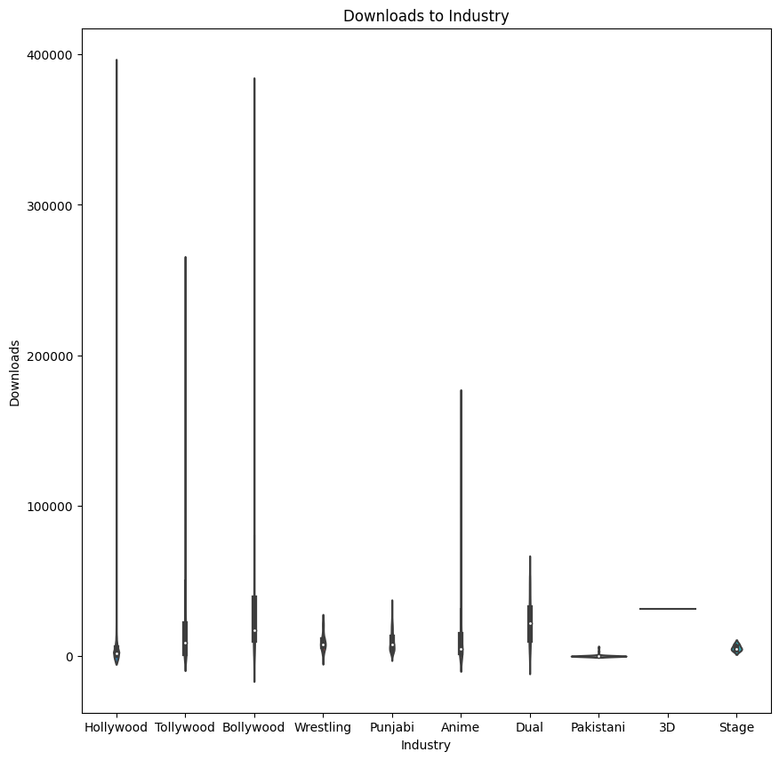

```python
#generate violin plot to show distribution of website downloads by industry


plt.figure(figsize = (10, 10))
g = sns.violinplot(x = 'industry', y = 'downloads', data = movie_data)
g.set_xticklabels(['Hollywood','Tollywood', 'Bollywood','Wrestling','Punjabi','Anime','Dual','Pakistani', '3D', 'Stage'])

plt.title("Downloads to Industry")
plt.xlabel("Industry")
plt.ylabel("Downloads")
```

The violin plots look very similar, even in their unfortunate variance where one can see "needles" shoot upward from a regular distribution. This appearance implies the presence of a very few number of outliers in the higher end of the view and download counts -- "celebrities" among the movies that garnered more attention.

Because there seems to be a general similarity between the view and download counts, there seems to be a correlation. We are able to see a linear correlation by plotting the two fields in a scatter plot with regression line.

```
<module 'matplotlib.pyplot' from 'C:\\Users\\peter\\AppData\\Local\\Packages\\PythonSoftwareFoundation.Python.3.10_qbz5n2kfra8p0\\LocalCache\\local-packages\\Python310\\site-packages\\matplotlib\\pyplot.py'>
```

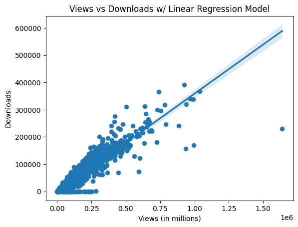

```python
movie_data.plot.scatter('views', 'downloads')
sns.regplot(x = "views", y = "downloads", data = movie_data)
plt.title("Views vs Downloads w/ Linear Regression Model")
plt.xlabel("Views (in millions)")
plt.ylabel("Downloads")
plt
```

We created a scatterplot graph using the views of the movies and the downloads corresponding to the views. We then created a linear regression model with this data. This shows us that as the views of the movie increase, the downloads for the movie also increase. This correlation shows that piracy increases as the views of the movies increase. With the OLS it shows that downloads increase by 0.3607 for every view. The p value is zero so there is a clear correlation between views the movie gets and the downloads that happen.

```python
import statsmodels.formula.api

result1 = statsmodels.formula.api.ols(formula = "downloads ~ views", data = movie_data).fit()
print (result1.summary())
```

```
                            OLS Regression Results
==============================================================================
Dep. Variable:              downloads   R-squared:                       0.899
Model:                            OLS   Adj. R-squared:                  0.899
Method:                 Least Squares   F-statistic:                 1.658e+05
Date:                Fri, 12 May 2023   Prob (F-statistic):               0.00
Time:                        23:49:55   Log-Likelihood:            -1.9275e+05
No. Observations:               18556   AIC:                         3.855e+05
Df Residuals:                   18554   BIC:                         3.855e+05
Df Model:                           1
Covariance Type:            nonrobust
==============================================================================
                 coef    std err          t      P>|t|      [0.025      0.975]
------------------------------------------------------------------------------
Intercept  -2108.3328     66.561    -31.675      0.000   -2238.798   -1977.868
views          0.3607      0.001    407.214      0.000       0.359       0.362
==============================================================================
Omnibus:                    22561.288   Durbin-Watson:                   1.555
Prob(Omnibus):                  0.000   Jarque-Bera (JB):         72464789.527
Skew:                          -5.415   Prob(JB):                         0.00
Kurtosis:                     308.953   Cond. No.                     8.68e+04
==============================================================================

Notes:
[1] Standard Errors assume that the covariance matrix of the errors is correctly specified.
[2] The condition number is large, 8.68e+04. This might indicate that there are
strong multicollinearity or other numerical problems.
```

A time delta field is the time between the release date of the movie and the date it was posted on the pirated website.

```python
movie_data['time_delta'] = movie_data['posted_date'] - movie_data['release_date']
movie_data.head()
```

|  | IMDb-rating | downloads | industry | language | posted_date | release_date | title | views | time_delta |
| --- | --- | --- | --- | --- | --- | --- | --- | --- | --- |
| 0 | 4.8 | 304 | Hollywood / English | English | 2023-02-20 | 2023-01-28 | Little Dixie | 2794 | 23 days |
| 1 | 6.4 | 73 | Hollywood / English | English | 2023-02-20 | 2023-02-05 | Grilling Season: A Curious Caterer Mystery | 1002 | 15 days |
| 2 | 5.2 | 1427 | Hollywood / English | English,Hindi | 2021-04-20 | 2021-06-18 | In the Earth | 14419 | -59 days |
| 3 | 8.1 | 1549 | Tollywood | Hindi | 2023-02-20 | 2023-02-17 | Vaathi | 4878 | 3 days |
| 4 | 4.6 | 657 | Tollywood | Hindi | 2023-02-20 | 2023-01-26 | Alone | 2438 | 25 days |

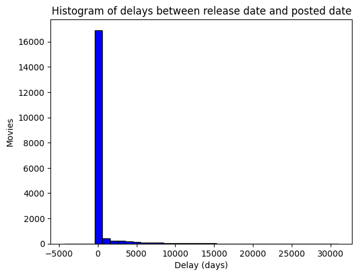

```python
deltas = pd.to_numeric(movie_data['time_delta'].dt.days, downcast='integer')

plt.hist(deltas, color = 'blue', edgecolor = 'black',
         bins = int(180/5))

plt.title('Histogram of delays between release date and posted date')
plt.xlabel('Delay (days)')
plt.ylabel('Movies')
```

```python
deltas.describe()
```

```
count    18556.000000
mean       454.867482
std       1840.567949
min      -4298.000000
25%          1.000000
50%          7.000000
75%         99.000000
max      31013.000000
Name: time_delta, dtype: float64
```

```python
sample = deltas[deltas.ge(-5) & deltas.le(80)]

sample.describe()
```

```
count    12872.000000
mean        11.866299
std         20.014622
min         -5.000000
25%          1.000000
50%          3.000000
75%         11.000000
max         80.000000
Name: time_delta, dtype: float64
```

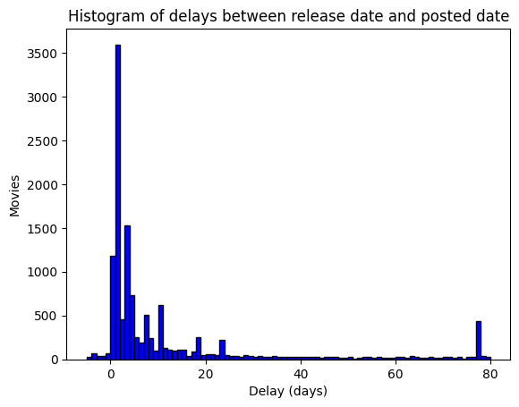

```python
plt.hist(sample, color = 'blue', edgecolor = 'black', bins = 85)

plt.title('Histogram of delays between release date and posted date')
plt.xlabel('Delay (days)')
plt.ylabel('Movies')
```

# Hypothesis Testing and Regression Analysis

As a regression model, we decided to test the yearly total of movie views. We needed to find the sum of each year for views and plot it against the minimum and maximum year of the dataframe. This will give us a model that is assumably quadratic.

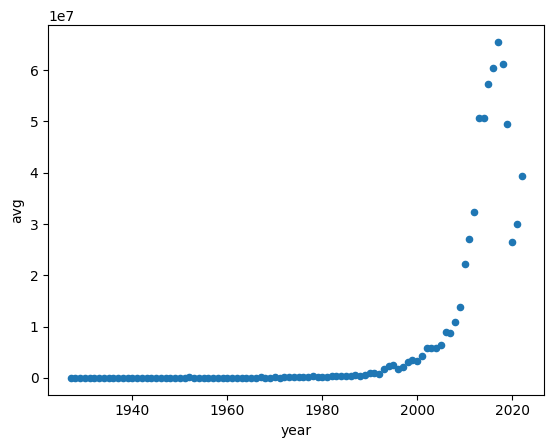

```python
#take min and max year
min_year = movie_data['release_date'].min().year
max_year = movie_data['release_date'].max().year

#initialize dataframe and array
yearly_avgs = pd.DataFrame(columns=['year', 'avg'])
avgs = []

#initialize iterator year at minimum year of dataframe
year = min_year
for i in range(min_year, max_year):
    #dataframe of all release dates in the year
    temp = movie_data[movie_data['release_date'].dt.year == year]
    #sum of all views in that year
    value_avg = temp['views'].sum()
    #append to dataframe views
    avgs.append(value_avg)
    #increment year
    year += 1


#fill dataframe
yearly_avgs['year'] = range(min_year, max_year)
yearly_avgs['avg'] = avgs
yearly_avgs.dropna(inplace=True)

yearly_avgs.plot.scatter('year', 'avg')
```

The rate of pirated movie viewings steadily increases in a quadratic fashion until it drops off towards the end. The end is anomalous behavior to an otherwise exponential-looking curve. It seems that pirated movies have taken a decrease in popularity starting around 2020.

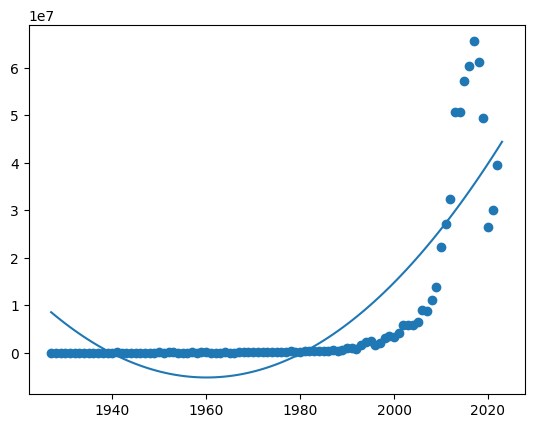

```python
model = np.poly1d(np.polyfit(yearly_avgs['year'], yearly_avgs['avg'], 2))

polyline = np.linspace(min_year, max_year, 100)
plt.scatter(yearly_avgs['year'], yearly_avgs['avg'])
plt.plot (polyline, model(polyline))
plt.show()
```

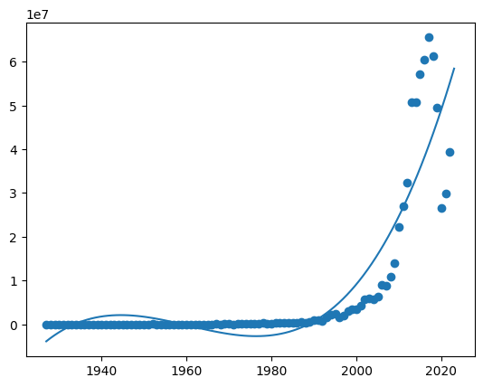

```python
model = np.poly1d(np.polyfit(yearly_avgs['year'], yearly_avgs['avg'], 3))

polyline = np.linspace(min_year, max_year, 100)
plt.scatter(yearly_avgs['year'], yearly_avgs['avg'])
plt.plot (polyline, model(polyline))
plt.show()
```

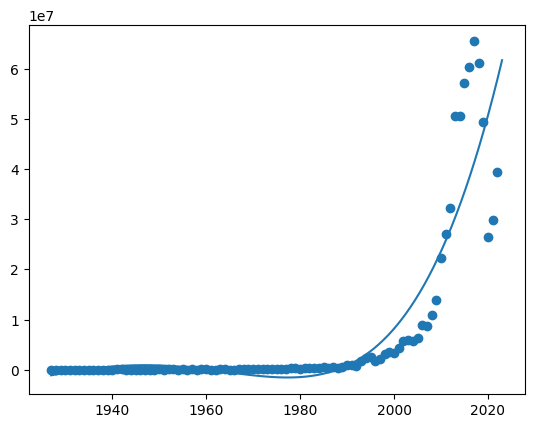

```python
model = np.poly1d(np.polyfit(yearly_avgs['year'], yearly_avgs['avg'], 4))

polyline = np.linspace(min_year, max_year, 100)
plt.scatter(yearly_avgs['year'], yearly_avgs['avg'])
plt.plot (polyline, model(polyline))
plt.show()
```

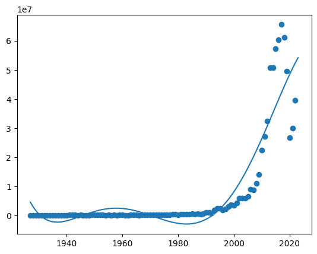

```python
model = np.poly1d(np.polyfit(yearly_avgs['year'], yearly_avgs['avg'], 5))

polyline = np.linspace(min_year, max_year, 100)
plt.scatter(yearly_avgs['year'], yearly_avgs['avg'])
plt.plot (polyline, model(polyline))
plt.show()
```

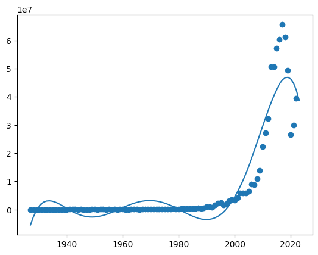

```python
model = np.poly1d(np.polyfit(yearly_avgs['year'], yearly_avgs['avg'], 6))

polyline = np.linspace(min_year, max_year, 100)
plt.scatter(yearly_avgs['year'], yearly_avgs['avg'])
plt.plot (polyline, model(polyline))
plt.show()
```

```python
model = np.poly1d(np.polyfit(yearly_avgs['year'], yearly_avgs['avg'], 4))
print(model)
```

```
       4            3            2
2.495 x - 1.94e+04 x + 5.66e+07 x - 7.336e+10 x + 3.565e+13
```

# Conclusion

Another noteworthy observation within the dataset is the prevalence of a substantial portion of pirated movies becoming available the very day a movie is officially released to the public. This highlights the instantaneous and widespread nature of piracy, which poses as the main challenge in protecting original property. It can be inferred that piracy swiftly capitalizes on the excitement of new movie releases, posing an immediate issue that needs to be dealt within the movies' release date.

As expected, the result of immediate pirated movie access also affects the total number of views per year. More specifically, the processed data shows that there is a spike of piracy views of movies released generally around and after the 2000s. It can be predicted that as the usage and speed of the internet also increased around the 2000s, the widespread distribution of pirated movies also proportionally increased with it. Timely uploads can easily distribute copyrighted material just as fast as movies are released by their distributors, which again proves to be a difficult challenge to combat.